# Métodos Numéricos - Tarea 2

## Ahora variamos p=0.95

```r
n1 <- 100
k <- 25
p <- 0.95
```

### n1 = 100

```r
n1 <- 100
k <- 25
p <- 0.95
mibinominal <- rbinom(n1, k, p)
```

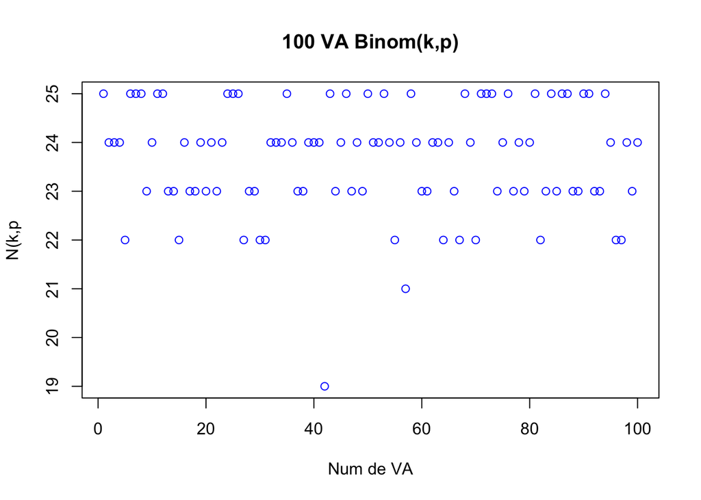

```r
plot(mibinominal, col="blue",
     main= "100 VA Binom(k,p)",
     xlab="Num de VA",
     ylab="N(k,p")
```

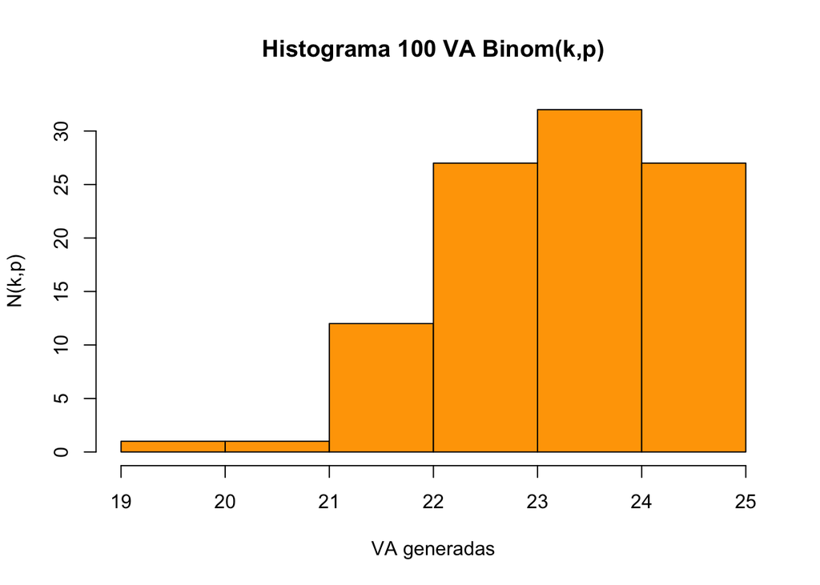

```r
hist(mibinominal, main= "Histograma 100 VA Binom(k,p)",
     col = "orange",
     xlab = "VA generadas",
     ylab = "N(k,p)")
```

```r
n1 <- 100
k <- 25
p <- 0.95
mibinominal <- rbinom(n1, k, p)
```

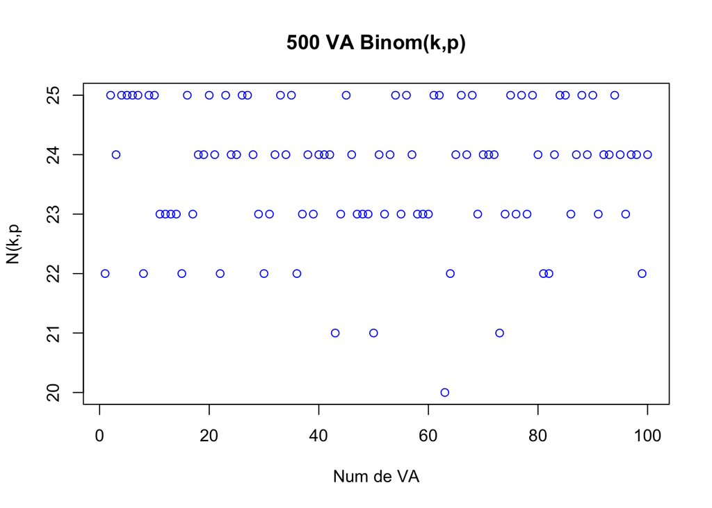

```r
plot(mibinominal, col="blue",
     main= "500 VA Binom(k,p)",
     xlab="Num de VA",
     ylab="N(k,p")
```

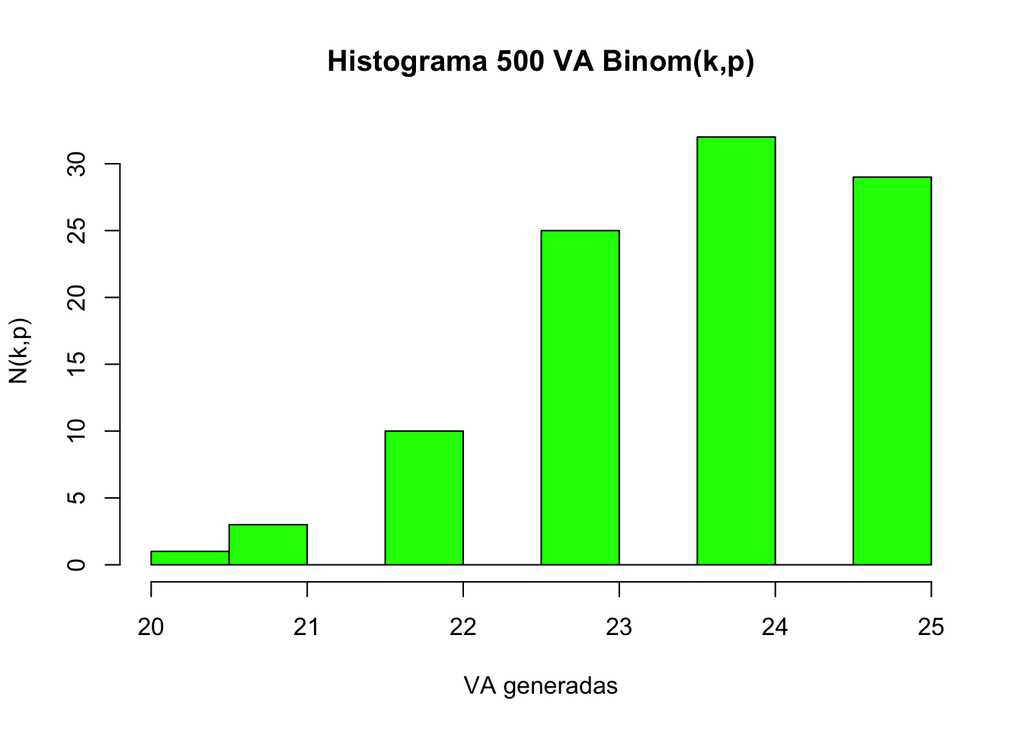

```r
hist(mibinominal, main= "Histograma 500 VA Binom(k,p)",
     col = "green",
     xlab = "VA generadas",
     ylab = "N(k,p)")
```

```r
n1 <- 100
k <- 25
p <- 0.95
mibinominal <- rbinom(n1, k, p)
```

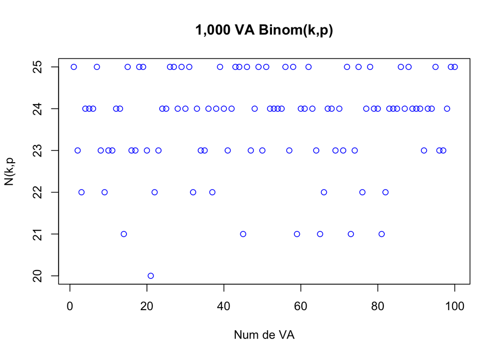

```r
plot(mibinominal, col="blue",
     main= "1,000 VA Binom(k,p)",
     xlab="Num de VA",
     ylab="N(k,p")
```

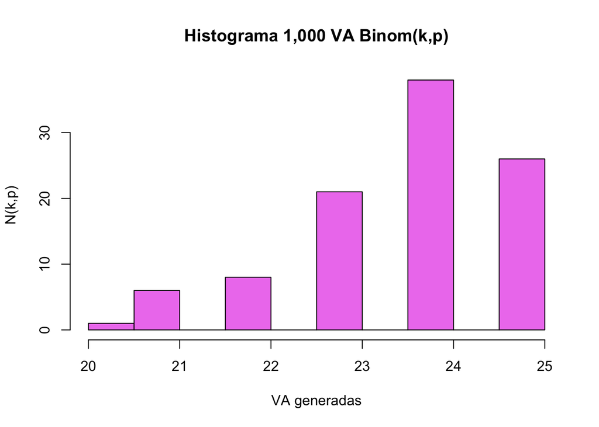

```r
hist(mibinominal, main= "Histograma 1,000 VA Binom(k,p)",
     col = "violet",
     xlab = "VA generadas",
     ylab = "N(k,p)")
```

```r
n1 <- 100
k <- 25
p <- 0.95
mibinominal <- rbinom(n1, k, p)
```

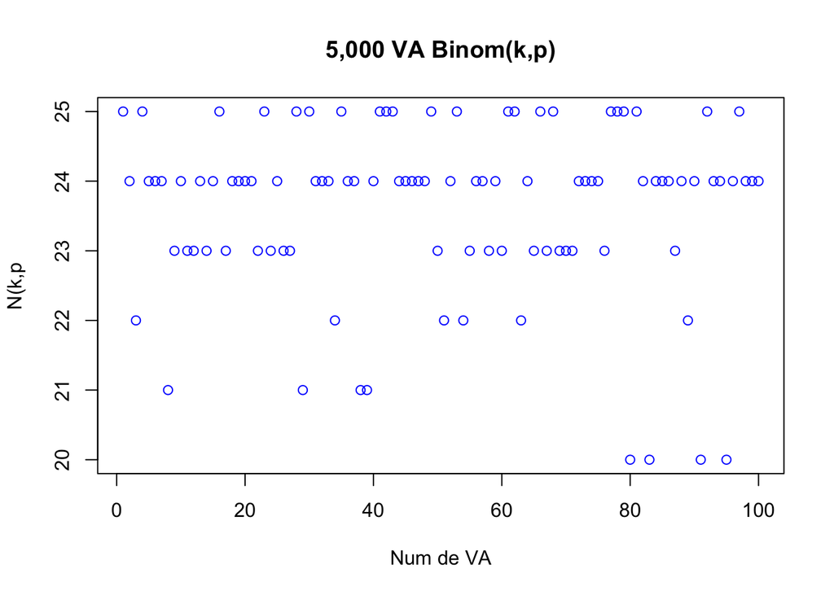

```r
plot(mibinominal, col="blue",
     main= "5,000 VA Binom(k,p)",
     xlab="Num de VA",
     ylab="N(k,p")
```

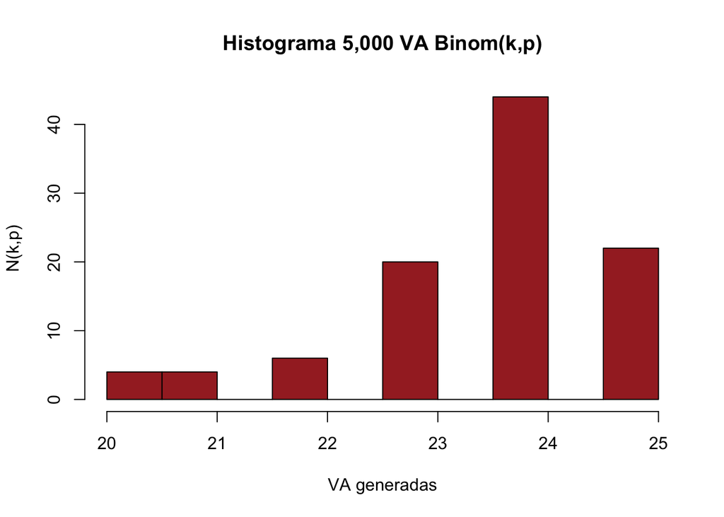

```r
hist(mibinominal, main= "Histograma 5,000 VA Binom(k,p)",
     col = "brown",
     xlab = "VA generadas",
     ylab = "N(k,p)")
```

```r
n1 <- 100
k <- 25
p <- 0.95
mibinominal <- rbinom(n1, k, p)
```

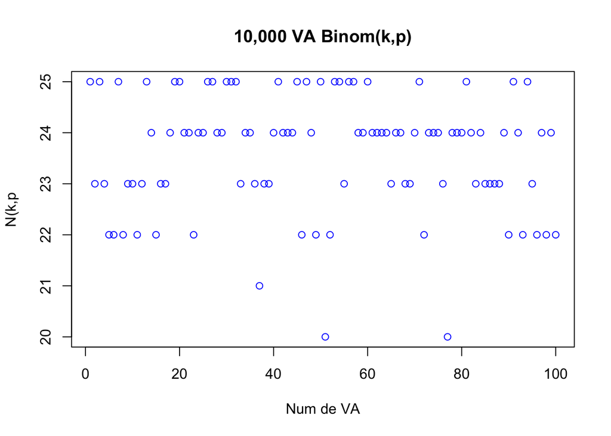

```r
plot(mibinominal, col="blue",
     main= "10,000 VA Binom(k,p)",
     xlab="Num de VA",
     ylab="N(k,p")
```

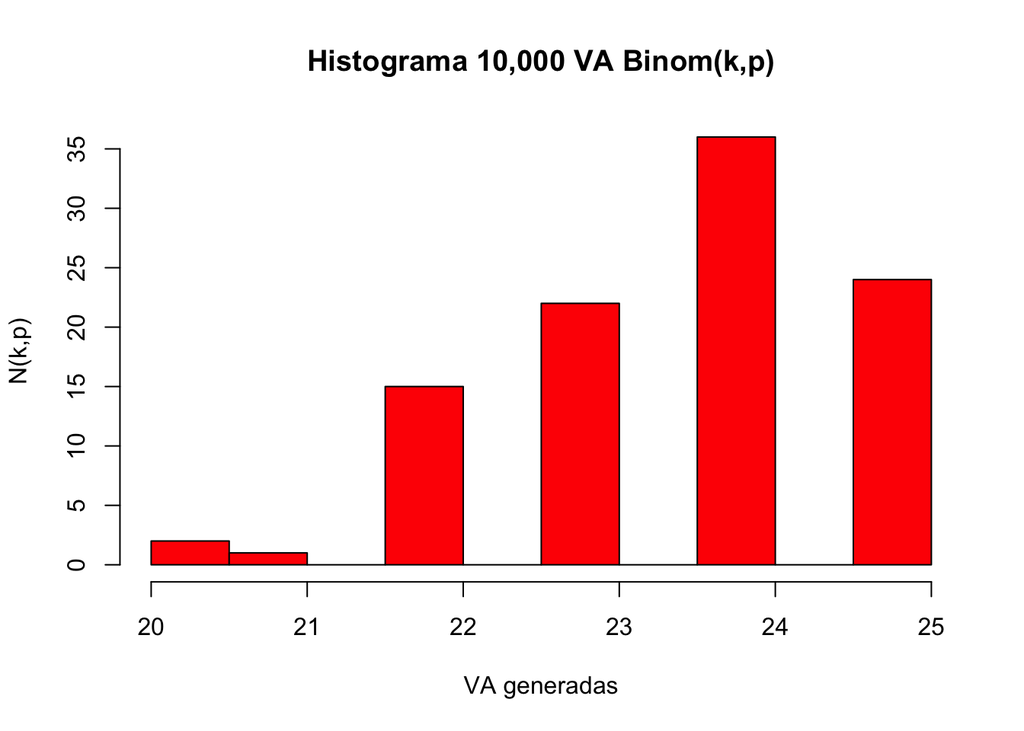

```r
hist(mibinominal, main= "Histograma 10,000 VA Binom(k,p)",
     col = "red",
     xlab = "VA generadas",
     ylab = "N(k,p)")
```

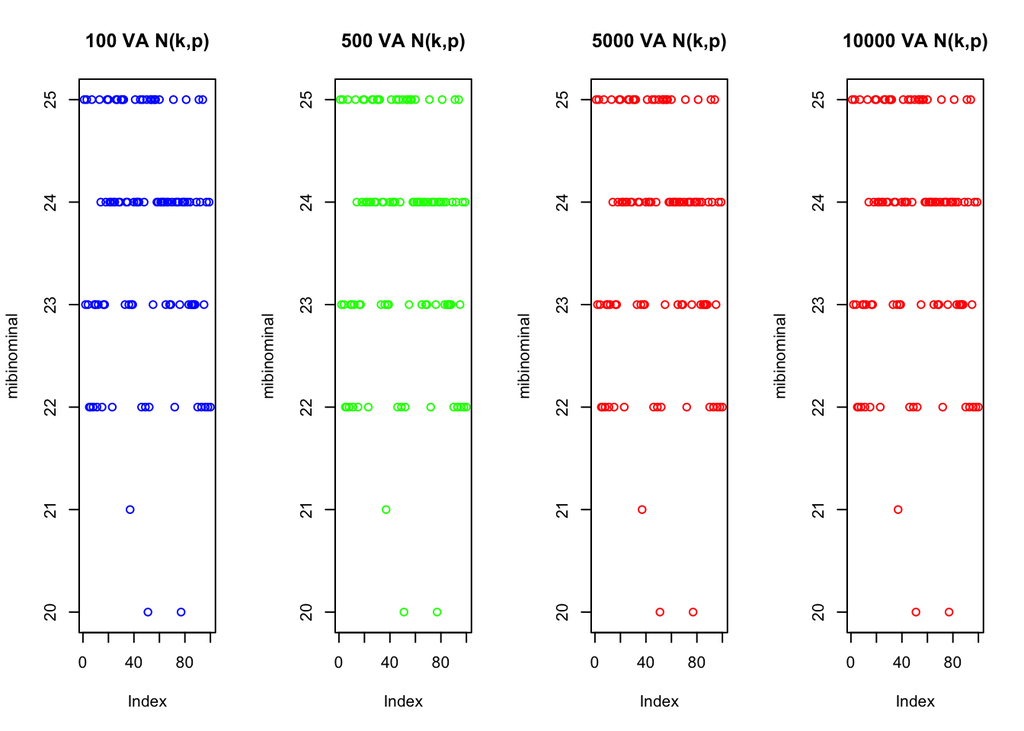

```r
par(mfrow = c(1, 4))
plot(mibinominal, col="blue",
     main= "100 VA N(k,p)")
plot(mibinominal, col="green",
     main= "500 VA N(k,p)")
plot(mibinominal, col="red",
     main= "5000 VA N(k,p)")
     plot(mibinominal, col="red",
     main= "10000 VA N(k,p)")
```

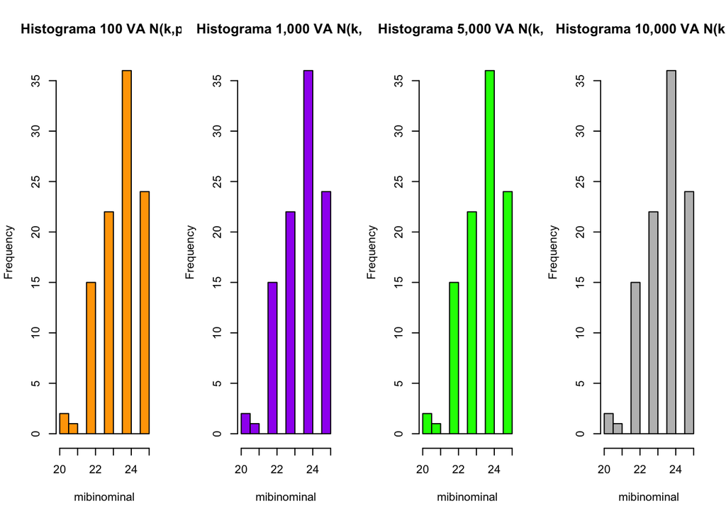

```r
par(mfrow = c(1, 4))
hist(mibinominal, main= "Histograma 100 VA N(k,p)",
     col = "orange")
hist(mibinominal, main= "Histograma 1,000 VA N(k,p)",
     col = "purple")
hist(mibinominal, main= "Histograma 5,000 VA N(k,p)",
     col = "green")
hist(mibinominal, main= "Histograma 10,000 VA N(k,p)",
     col = "grey")
```

## Generacion de Poisson

```r
n1 <- 100
milambda <- 0.75
mipoisson <- rpois(n1, milambda)
```

```r
etiqueta_Y <- paste0("Poisson(",n1,",", milambda,")")
```

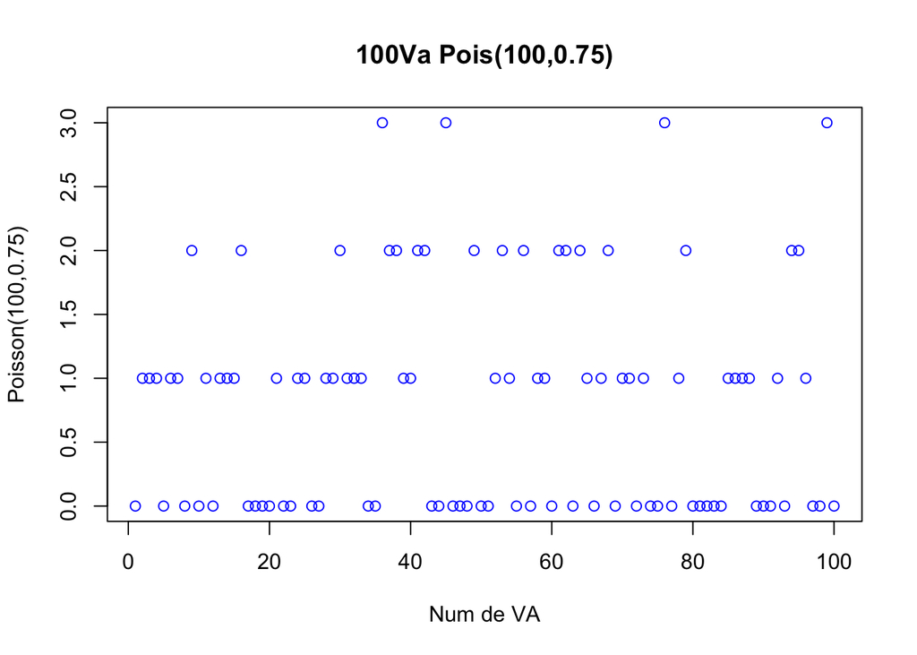

```r
mititulo <- paste0(n1, "Va Pois(",n1,",",milambda,")")
plot(mipoisson, col = "blue",
     main= mititulo,
     xlab = "Num de VA",
     ylab = etiqueta_Y)
```

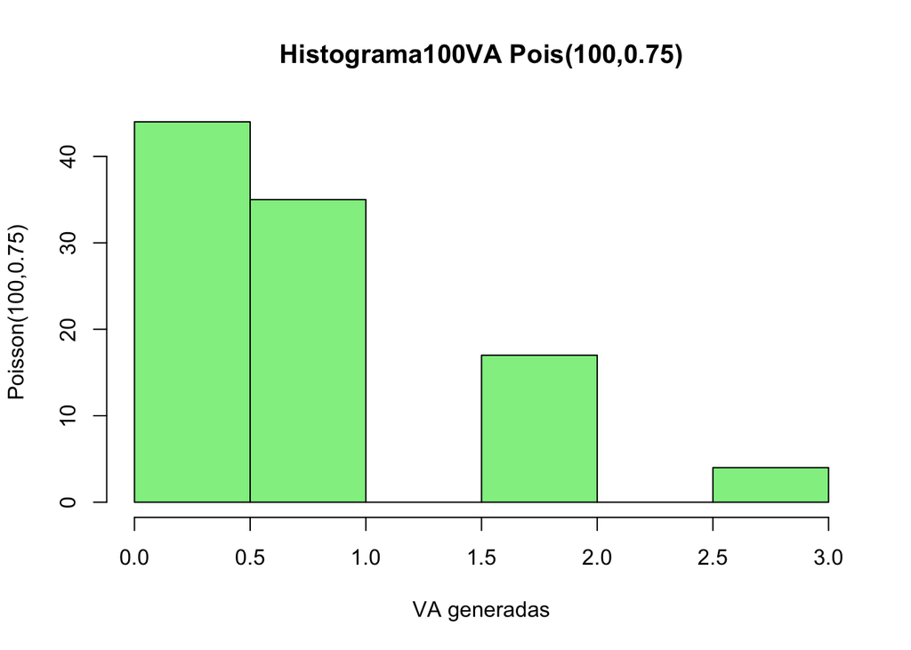

```r
mititulo <- paste0("Histograma" ,n1,"VA Pois(",n1,",",milambda,")")
hist(mipoisson, main=mititulo,
     col = "lightgreen",
     xlab = "VA generadas",
     ylab = etiqueta_Y)
```

## Inversa de una matriz

```r
A=matrix(c(1,3,-2,1,
 1,4,-1,2,
 0,1,-1,4,
 2,6,1,2),nrow = 4,byrow = TRUE)
(A)
```

```
##      [,1] [,2] [,3] [,4]
## [1,]    1    3   -2    1
## [2,]    1    4   -1    2
## [3,]    0    1   -1    4
## [4,]    2    6    1    2
```

```r
Aorig<- A
```

```r
I = diag(4);(I)
```

```
##      [,1] [,2] [,3] [,4]
## [1,]    1    0    0    0
## [2,]    0    1    0    0
## [3,]    0    0    1    0
## [4,]    0    0    0    1
```

```r
AInv <- cbind(A,I);
(AInv)
```

```
##      [,1] [,2] [,3] [,4] [,5] [,6] [,7] [,8]
## [1,]    1    3   -2    1    1    0    0    0
## [2,]    1    4   -1    2    0    1    0    0
## [3,]    0    1   -1    4    0    0    1    0
## [4,]    2    6    1    2    0    0    0    1
```

```r
A <- AInv
l21 <- A[2,1]/A[1,1];(l21)
```

```
## [1] 1
```

```r
l31 <- A[3,1]/A[1,1];(l31)
```

```
## [1] 0
```

```r
l41 <- A[4,1]/A[1,1];(l41)
```

```
## [1] 2
```

```r
A[2,] <- A[2,]-l21*A[1,];
A[3,] <- A[3,]-l31*A[1,];
A[4,] <- A[4,]-l41*A[1,];
(A)
```

```
##      [,1] [,2] [,3] [,4] [,5] [,6] [,7] [,8]
## [1,]    1    3   -2    1    1    0    0    0
## [2,]    0    1    1    1   -1    1    0    0
## [3,]    0    1   -1    4    0    0    1    0
## [4,]    0    0    5    0   -2    0    0    1
```

```r
Atmp <- A[2,]
A[2,] <- A[3,]
A[3,] <- Atmp
(A)
```

```
##      [,1] [,2] [,3] [,4] [,5] [,6] [,7] [,8]
## [1,]    1    3   -2    1    1    0    0    0
## [2,]    0    1   -1    4    0    0    1    0
## [3,]    0    1    1    1   -1    1    0    0
## [4,]    0    0    5    0   -2    0    0    1
```

```r
l32 <- A[3,2]/A[2,2];(l32)
```

```
## [1] 1
```

```r
l42 <- A[4,2]/A[2,2];(l42)
```

```
## [1] 0
```

```r
A[3,] <- A[3,]-l32*A[2,];
A[4,] <- A[4,]-l42*A[2,];
(A)
```

```
##      [,1] [,2] [,3] [,4] [,5] [,6] [,7] [,8]
## [1,]    1    3   -2    1    1    0    0    0
## [2,]    0    1   -1    4    0    0    1    0
## [3,]    0    0    2   -3   -1    1   -1    0
## [4,]    0    0    5    0   -2    0    0    1
```

```r
esc <- 1/A[3,3]
A[3,] <- esc*A[3,]
(A)
```

```
##      [,1] [,2] [,3] [,4] [,5] [,6] [,7] [,8]
## [1,]    1    3   -2  1.0  1.0  0.0  0.0    0
## [2,]    0    1   -1  4.0  0.0  0.0  1.0    0
## [3,]    0    0    1 -1.5 -0.5  0.5 -0.5    0
## [4,]    0    0    5  0.0 -2.0  0.0  0.0    1
```

```r
l43 <- A[4,3]/A[3,3];(l43)
```

```
## [1] 5
```

```r
A[4,] <- A[4,]-l43*A[3,];
(A)
```

```
##      [,1] [,2] [,3] [,4] [,5] [,6] [,7] [,8]
## [1,]    1    3   -2  1.0  1.0  0.0  0.0    0
## [2,]    0    1   -1  4.0  0.0  0.0  1.0    0
## [3,]    0    0    1 -1.5 -0.5  0.5 -0.5    0
## [4,]    0    0    0  7.5  0.5 -2.5  2.5    1
```

```r
esc <- 1/A[4,4]
A[4,] <- esc*A[4,]
(A)
```

```
##      [,1] [,2] [,3] [,4]        [,5]       [,6]       [,7]      [,8]
## [1,]    1    3   -2  1.0  1.00000000  0.0000000  0.0000000 0.0000000
## [2,]    0    1   -1  4.0  0.00000000  0.0000000  1.0000000 0.0000000
## [3,]    0    0    1 -1.5 -0.50000000  0.5000000 -0.5000000 0.0000000
## [4,]    0    0    0  1.0  0.06666667 -0.3333333  0.3333333 0.1333333
```

```r
l34 <- A[3,4]/A[4,4];(l34); A[3,] <- A[3,]-l34*A[4,]
```

```
## [1] -1.5
```

```r
l24 <- A[2,4]/A[4,4];(l24); A[2,] <- A[2,]-l24*A[4,]
```

```
## [1] 4
```

```r
l14 <- A[1,4]/A[4,4];(l14); A[1,] <- A[1,]-l14*A[4,]
```

```
## [1] 1
```

```r
(A)
```

```
##      [,1] [,2] [,3] [,4]        [,5]       [,6]       [,7]       [,8]
## [1,]    1    3   -2    0  0.93333333  0.3333333 -0.3333333 -0.1333333
## [2,]    0    1   -1    0 -0.26666667  1.3333333 -0.3333333 -0.5333333
## [3,]    0    0    1    0 -0.40000000  0.0000000  0.0000000  0.2000000
## [4,]    0    0    0    1  0.06666667 -0.3333333  0.3333333  0.1333333
```

```r
l23 <- A[2,3]/A[3,3];(l23); A[2,] <- A[2,]-l23*A[3,]
```

```
## [1] -1
```

```r
l13 <- A[1,3]/A[3,3];(l13); A[1,] <- A[1,]-l13*A[3,]
```

```
## [1] -2
```

```r
(A)
```

```
##      [,1] [,2] [,3] [,4]        [,5]       [,6]       [,7]       [,8]
## [1,]    1    3    0    0  0.13333333  0.3333333 -0.3333333  0.2666667
## [2,]    0    1    0    0 -0.66666667  1.3333333 -0.3333333 -0.3333333
## [3,]    0    0    1    0 -0.40000000  0.0000000  0.0000000  0.2000000
## [4,]    0    0    0    1  0.06666667 -0.3333333  0.3333333  0.1333333
```

```r
l12 <- A[1,2]/A[2,2];(l12); A[1,] <- A[1,]-l12*A[2,]
```

```
## [1] 3
```

```r
(A)
```

```
##      [,1] [,2] [,3] [,4]        [,5]       [,6]       [,7]       [,8]
## [1,]    1    0    0    0  2.13333333 -3.6666667  0.6666667  1.2666667
## [2,]    0    1    0    0 -0.66666667  1.3333333 -0.3333333 -0.3333333
## [3,]    0    0    1    0 -0.40000000  0.0000000  0.0000000  0.2000000
## [4,]    0    0    0    1  0.06666667 -0.3333333  0.3333333  0.1333333
```

```r
AInv <- A[,5:8]; (AInv)
```

```
##             [,1]       [,2]       [,3]       [,4]
## [1,]  2.13333333 -3.6666667  0.6666667  1.2666667
## [2,] -0.66666667  1.3333333 -0.3333333 -0.3333333
## [3,] -0.40000000  0.0000000  0.0000000  0.2000000
## [4,]  0.06666667 -0.3333333  0.3333333  0.1333333
```

```r
IdCalc <- Aorig%*%AInv;
(IdCalc)
```

```
##               [,1]          [,2]         [,3]          [,4]
## [1,]  1.000000e+00 -5.551115e-17 5.551115e-17 -2.775558e-17
## [2,] -3.053113e-16  1.000000e+00 1.110223e-16  0.000000e+00
## [3,] -5.551115e-17  0.000000e+00 1.000000e+00  0.000000e+00
## [4,] -5.273559e-16 -1.110223e-16 1.110223e-16  1.000000e+00
```

## Factorización LU

### Ejemplo 1

```r
A=matrix(c(1,1,1,1,
 2,3,1,5,
 -1,1,-5,3,
 3,1,7,-2),byrow = TRUE,nrow = 4)
(A)
```

```
##      [,1] [,2] [,3] [,4]
## [1,]    1    1    1    1
## [2,]    2    3    1    5
## [3,]   -1    1   -5    3
## [4,]    3    1    7   -2
```

```r
b=matrix(c(10,31,-2,18),nrow = 4)
(b)
```

```
##      [,1]
## [1,]   10
## [2,]   31
## [3,]   -2
## [4,]   18
```

```r
Ab <- cbind(A,b); (Ab)
```

```
##      [,1] [,2] [,3] [,4] [,5]
## [1,]    1    1    1    1   10
## [2,]    2    3    1    5   31
## [3,]   -1    1   -5    3   -2
## [4,]    3    1    7   -2   18
```

Los pivotes se definen como $a_{kk}^{(k)}$, luego construimos los multiplicadores: $l_{i,k}=a_{ik}^{(k)}/a_{kk}^{(k)}$, $l_{21}=a_{21}/a_{aa}$ y $l_{31}=a_{31}/a_{11}$ y $l_{41}=a_{41}/a_{11}$

```r
A <- Ab;
l21 <- A[2,1]/A[1,1];(l21)
```

```
## [1] 2
```

```r
l31 <- A[3,1]/A[1,1];(l31)
```

```
## [1] -1
```

```r
l41 <- A[4,1]/A[1,1];(l41)
```

```
## [1] 3
```

Construimos la matriz $U$, donde las entradas $a_{ij}^{(k+1)}=a_{ik}^{(k)}- l_{ik}\times a_{kj}^{(k)}$

```r
A[2,] <- A[2,]-l21*A[1,]; (A[2,])
```

```
## [1]  0  1 -1  3 11
```

```r
A[3,] <- A[3,]-l31*A[1,]; (A[3,])
```

```
## [1]  0  2 -4  4  8
```

```r
A[4,] <- A[4,]-l41*A[1,]; (A[4,])
```

```
## [1]   0  -2   4  -5 -12
```

Es decir la matriz resultante es:

```r
(A)
```

```
##      [,1] [,2] [,3] [,4] [,5]
## [1,]    1    1    1    1   10
## [2,]    0    1   -1    3   11
## [3,]    0    2   -4    4    8
## [4,]    0   -2    4   -5  -12
```

entonces el pivote es $A_{22} = 1$, calculemos los $l_{32}$ y $l_{42}$

```r
l32 <- A[3,2]/A[2,2];(l32)
```

```
## [1] 2
```

```r
l42 <- A[4,2]/A[2,2];(l42)
```

```
## [1] -2
```

Haciendo cero debajo del pivote

```r
A[3,] <- A[3,]-l32*A[2,];(A[3,])
```

```
## [1]   0   0  -2  -2 -14
```

```r
A[4,] <- A[4,]-l42*A[2,];(A[4,])
```

```
## [1]  0  0  2  1 10
```

La matriz $A$ queda de la forma:

```r
(A)
```

```
##      [,1] [,2] [,3] [,4] [,5]
## [1,]    1    1    1    1   10
## [2,]    0    1   -1    3   11
## [3,]    0    0   -2   -2  -14
## [4,]    0    0    2    1   10
```

por tanto el pivote es $A_{33}=-2$, y resta calcylar $l_{43}$

```r
l43 <- A[4,3]/A[3,3];(l43)
```

```
## [1] -1
```

haciendo cero debajo del pivote

```r
A[4,] <- A[4,]-l43*A[3,];(A[4,])
```

```
## [1]  0  0  0 -1 -4
```

Por lo tanto la matriz $A$ resultante es

```r
(A)
```

```
##      [,1] [,2] [,3] [,4] [,5]
## [1,]    1    1    1    1   10
## [2,]    0    1   -1    3   11
## [3,]    0    0   -2   -2  -14
## [4,]    0    0    0   -1   -4
```

entonces podemos construir la matriz $L$ con los valores $l_{ij}$ calculados en los pasos anteriores

```r
L=diag(4);(L)
```

```
##      [,1] [,2] [,3] [,4]
## [1,]    1    0    0    0
## [2,]    0    1    0    0
## [3,]    0    0    1    0
## [4,]    0    0    0    1
```

```r
L[2,1] <- l21
L[3,1] <- l31
L[4,1] <- l41
L[3,2] <- l32
L[4,2] <- l42
L[4,3] <- l43
(L)
```

```
##      [,1] [,2] [,3] [,4]
## [1,]    1    0    0    0
## [2,]    2    1    0    0
## [3,]   -1    2    1    0
## [4,]    3   -2   -1    1
```

```r
U <- A[,1:4];(U)
```

```
##      [,1] [,2] [,3] [,4]
## [1,]    1    1    1    1
## [2,]    0    1   -1    3
## [3,]    0    0   -2   -2
## [4,]    0    0    0   -1
```

Verifiquemos que efectivamente $A=LU$

```r
Acalculada <- L%*%U; (Acalculada)
```

```
##      [,1] [,2] [,3] [,4]
## [1,]    1    1    1    1
## [2,]    2    3    1    5
## [3,]   -1    1   -5    3
## [4,]    3    1    7   -2
```

### Ejemplo 2

Apliquemos lo desarrollado para la siguiente matriz $A$

```r
A=matrix(c(4,0,1,1,
 3,1,3,1,
 0,1,2,0,
 3,2,4,1),nrow = 4,byrow = TRUE);
(A)
```

```
##      [,1] [,2] [,3] [,4]
## [1,]    4    0    1    1
## [2,]    3    1    3    1
## [3,]    0    1    2    0
## [4,]    3    2    4    1
```

```r
b=matrix(c(5,6,13,1),nrow = 4);(b)
```

```
##      [,1]
## [1,]    5
## [2,]    6
## [3,]   13
## [4,]    1
```

```r
Ab <- cbind(A,b)
A <- Ab;
```

```r
l21 <- A[2,1]/A[1,1];(l21)
```

```
## [1] 0.75
```

```r
l31 <- A[3,1]/A[1,1];(l31)
```

```
## [1] 0
```

```r
l41 <- A[4,1]/A[1,1];(l41)
```

```
## [1] 0.75
```

```r
A[2,] <- A[2,]-l21*A[1,]; (A[2,])
```

```
## [1] 0.00 1.00 2.25 0.25 2.25
```

```r
A[3,] <- A[3,]-l31*A[1,]; (A[3,])
```

```
## [1]  0  1  2  0 13
```

```r
A[4,] <- A[4,]-l41*A[1,]; (A[4,])
```

```
## [1]  0.00  2.00  3.25  0.25 -2.75
```

```r
l32 <- A[3,2]/A[2,2];(l32)
```

```
## [1] 1
```

```r
l42 <- A[4,2]/A[2,2];(l42)
```

```
## [1] 2
```

```r
A[3,] <- A[3,]-l32*A[2,];(A[3,])
```

```
## [1]  0.00  0.00 -0.25 -0.25 10.75
```

```r
A[4,] <- A[4,]-l42*A[2,];(A[4,])
```

```
## [1]  0.00  0.00 -1.25 -0.25 -7.25
```

```r
l43 <- A[4,3]/A[3,3];(l43)
```

```
## [1] 5
```

```r
A[4,] <- A[4,]-l43*A[3,];(A[4,])
```

```
## [1]   0   0   0   1 -61
```

```r
L=diag(4);(L)
```

```
##      [,1] [,2] [,3] [,4]
## [1,]    1    0    0    0
## [2,]    0    1    0    0
## [3,]    0    0    1    0
## [4,]    0    0    0    1
```

```r
L[2,1] <- l21
L[3,1] <- l31
L[4,1] <- l41
L[3,2] <- l32
L[4,2] <- l42
L[4,3] <- l43;
(L)
```

```
##      [,1] [,2] [,3] [,4]
## [1,] 1.00    0    0    0
## [2,] 0.75    1    0    0
## [3,] 0.00    1    1    0
## [4,] 0.75    2    5    1
```

```r
U <- A[,1:4];(U)
```

```
##      [,1] [,2]  [,3]  [,4]
## [1,]    4    0  1.00  1.00
## [2,]    0    1  2.25  0.25
## [3,]    0    0 -0.25 -0.25
## [4,]    0    0  0.00  1.00
```

```r
Acalculada <- L%*%U; (Acalculada)
```

```
##      [,1] [,2] [,3] [,4]
## [1,]    4    0    1    1
## [2,]    3    1    3    1
## [3,]    0    1    2    0
## [4,]    3    2    4    1
```

### Ejercicio

Aplicar la factorización $LU$ a la matriz A definida por

```r
A=matrix(c(2,3,2,4,
 4,10,-4,0,
 -3,-2,-5,-2,
 -2,4,4,-7),nrow = 4,byrow = TRUE)
(A)
```

```
##      [,1] [,2] [,3] [,4]
## [1,]    2    3    2    4
## [2,]    4   10   -4    0
## [3,]   -3   -2   -5   -2
## [4,]   -2    4    4   -7
```

```r
B=matrix(c(10,31,-2,18),nrow = 4);(B)
```

```
##      [,1]
## [1,]   10
## [2,]   31
## [3,]   -2
## [4,]   18
```

```r
AB <- cbind(A,B); (AB)
```

```
##      [,1] [,2] [,3] [,4] [,5]
## [1,]    2    3    2    4   10
## [2,]    4   10   -4    0   31
## [3,]   -3   -2   -5   -2   -2
## [4,]   -2    4    4   -7   18
```

```r
A <- AB;
l21 <- A[2,1]/A[1,1];(l21)
```

```
## [1] 2
```

```r
l31 <- A[3,1]/A[1,1];(l31)
```

```
## [1] -1.5
```

```r
l41 <- A[4,1]/A[1,1];(l41)
```

```
## [1] -1
```

```r
A[2,] <- A[2,]-l21*A[1,]; (A[2,])
```

```
## [1]  0  4 -8 -8 11
```

```r
A[3,] <- A[3,]-l31*A[1,]; (A[3,])
```

```
## [1]  0.0  2.5 -2.0  4.0 13.0
```

```r
A[4,] <- A[4,]-l41*A[1,]; (A[4,])
```

```
## [1]  0  7  6 -3 28
```

```r
(A)
```

```
##      [,1] [,2] [,3] [,4] [,5]
## [1,]    2  3.0    2    4   10
## [2,]    0  4.0   -8   -8   11
## [3,]    0  2.5   -2    4   13
## [4,]    0  7.0    6   -3   28
```

```r
l32 <- A[3,2]/A[2,2];(l32)
```

```
## [1] 0.625
```

```r
l42 <- A[4,2]/A[2,2];(l42)
```

```
## [1] 1.75
```

```r
A[3,] <- A[3,]-l32*A[2,];(A[3,])
```

```
## [1] 0.000 0.000 3.000 9.000 6.125
```

```r
A[4,] <- A[4,]-l42*A[2,];(A[4,])
```

```
## [1]  0.00  0.00 20.00 11.00  8.75
```

```r
(A)
```

```
##      [,1] [,2] [,3] [,4]   [,5]
## [1,]    2    3    2    4 10.000
## [2,]    0    4   -8   -8 11.000
## [3,]    0    0    3    9  6.125
## [4,]    0    0   20   11  8.750
```

```r
l32 <- A[3,2]/A[2,2];(l32)
```

```
## [1] 0
```

```r
l42 <- A[4,2]/A[2,2];(l42)
```

```
## [1] 0
```

```r
A[3,] <- A[3,]-l32*A[2,];(A[3,])
```

```
## [1] 0.000 0.000 3.000 9.000 6.125
```

```r
A[4,] <- A[4,]-l42*A[2,];(A[4,])
```

```
## [1]  0.00  0.00 20.00 11.00  8.75
```

```r
(A)
```

```
##      [,1] [,2] [,3] [,4]   [,5]
## [1,]    2    3    2    4 10.000
## [2,]    0    4   -8   -8 11.000
## [3,]    0    0    3    9  6.125
## [4,]    0    0   20   11  8.750
```

```r
l43 <- A[4,3]/A[3,3];(l43)
```

```
## [1] 6.666667
```

```r
A[4,] <- A[4,]-l43*A[3,];(A[4,])
```

```
## [1]   0.00000   0.00000   0.00000 -49.00000 -32.08333
```

```r
(A)
```

```
##      [,1] [,2] [,3] [,4]      [,5]
## [1,]    2    3    2    4  10.00000
## [2,]    0    4   -8   -8  11.00000
## [3,]    0    0    3    9   6.12500
## [4,]    0    0    0  -49 -32.08333
```

```r
L=diag(4);(L)
```

```
##      [,1] [,2] [,3] [,4]
## [1,]    1    0    0    0
## [2,]    0    1    0    0
## [3,]    0    0    1    0
## [4,]    0    0    0    1
```

```r
L[2,1] <- l21
L[3,1] <- l31
L[4,1] <- l41
L[3,2] <- l32
L[4,2] <- l42
L[4,3] <- l43
(L)
```

```
##      [,1] [,2]     [,3] [,4]
## [1,]  1.0    0 0.000000    0
## [2,]  2.0    1 0.000000    0
## [3,] -1.5    0 1.000000    0
## [4,] -1.0    0 6.666667    1
```

```r
U <- A[,1:4];(U)
```

```
##      [,1] [,2] [,3] [,4]
## [1,]    2    3    2    4
## [2,]    0    4   -8   -8
## [3,]    0    0    3    9
## [4,]    0    0    0  -49
```

```r
Acalculada <- L%*%U; (Acalculada)
```

```
##      [,1] [,2] [,3] [,4]
## [1,]    2  3.0    2    4
## [2,]    4 10.0   -4    0
## [3,]   -3 -4.5    0    3
## [4,]   -2 -3.0   18    7
```

### Notas importantes

**Nota 1** Si se fija $l_{ii}=1$ se le denomina factorizacion *Doolitle*. **Nota 2** Una matriz $A$ tiene factorización de Doolitle si y sólo sí se le puede aplicar el metodo de eliminación de Gauss sin pivoteo. **Nota 3** Si $U=L^{T}$ entonces la factorización se le denomina *factorización de Cholesky*. **Nota 4** Si la matriz es simétrica y definida positiva, entonces $A=LL^{T}$.

## 05-11

```r
rm(list = ls())
```

```r
x <- c(1, 2, 4)
y <- c(2, 3, 7)
```

```r
A <- cbind(1, x, x^2)
```

```r
a <- solve(A, y)
```

```r
names(a) <- c("a0", "a1", "a2")
```

```r
cat("Coeficientes del polinomio:\n")
```

```
## Coeficientes del polinomio:
```

```r
print(a)
```

```
##           a0           a1           a2
## 1.666667e+00 9.251859e-17 3.333333e-01
```

```r
cat("\nEl polinomio es:\n")
```

```
##
## El polinomio es:
```

```r
cat(sprintf("P(x) = %.3f + %.3f*x + %.3f*x^2\n\n", a[1], a[2], a[3]))
```

```
## P(x) = 1.667 + 0.000*x + 0.333*x^2
```

```r
P <- function(x) a[1] + a[2]*x + a[3]*x^2
```

```r
valores <- P(x)
resultado <- data.frame(x, y_real = y, y_calculado = valores)
print(resultado)
```

```
##   x y_real y_calculado
## 1 1      2           2
## 2 2      3           3
## 3 4      7           7
```

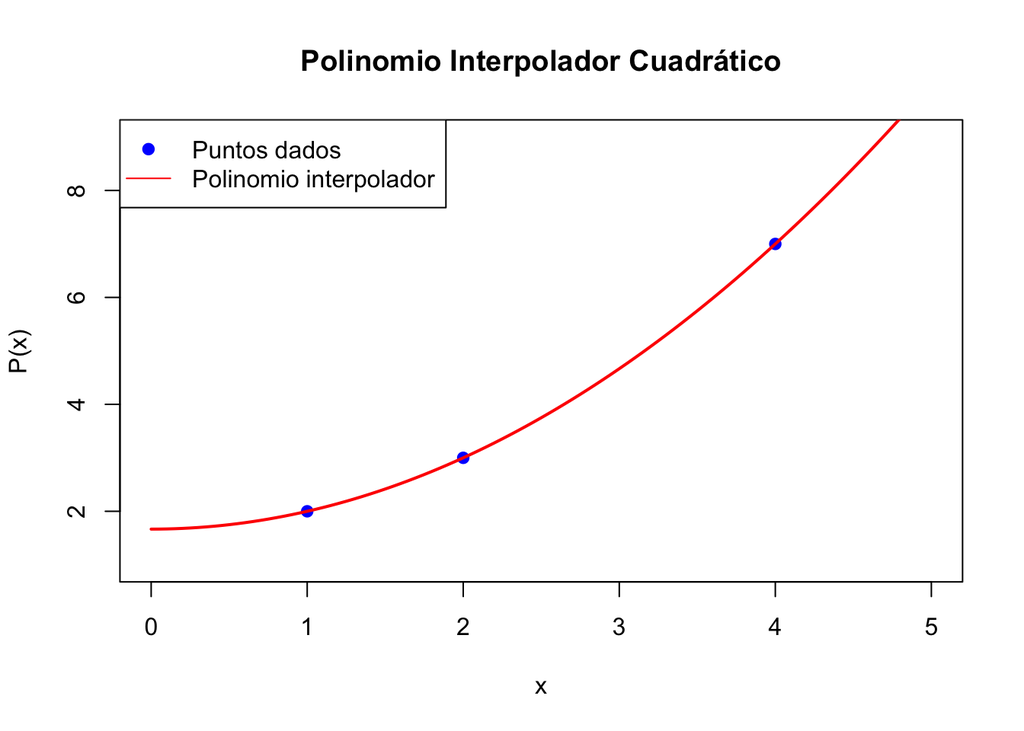

```r
plot(x, y, pch = 19, col = "blue",
     main = "Polinomio Interpolador Cuadrático",
     xlab = "x", ylab = "P(x)",
     xlim = c(min(x)-1, max(x)+1),
     ylim = c(min(y)-1, max(y)+2))
curve(P, from = min(x)-1, to = max(x)+1,
      add = TRUE, col = "red", lwd = 2)
legend("topleft", legend = c("Puntos dados", "Polinomio interpolador"),
       col = c("blue", "red"), pch = c(19, NA), lty = c(NA,1))
```

```r
if (all(abs(y - valores) < 1e-10)) {
  cat("\n El polinomio pasa exactamente por todos los puntos.\n")
} else {
  cat("\n El polinomio no pasa exactamente por todos los puntos.\n")
}
```

```
##
##  El polinomio pasa exactamente por todos los puntos.
```

## Gauss-Seidel

```r
A <- matrix(c(
  4,-1, 0, 0, 0,
 -1, 4,-1, 0, 0,
  0,-1, 4,-1, 0,
  0, 0,-1, 4,-1,
  0, 0, 0,-1, 4
), nrow = 5, byrow = TRUE)
b <- c(1,2,3,4,5)
```

$$x_i^{(k+1)} = \frac{1}{a_{ii}}\left( b_i - \sum_{j<i} a_{ij}
x_j^{(k+1)} - \sum_{j>i} a_{ij} x_j^{(k)} \right).$$

```r
x <- rep(0,5)  # x^(0) = (0,0,0,0,0)
cat("x^(0) =", paste(sprintf("%.8f", x), collapse=", "), "\n")
```

```
## x^(0) = 0.00000000, 0.00000000, 0.00000000, 0.00000000, 0.00000000
```

### Interacion 1

```r
# ---- Iteración 1 (escrita a mano, sin bucles) ----
x_old <- x
cat("\nIteración 1\n")
```

```
##
## Iteración 1
```

```r
# Fila 1: 4 x1 - x2 = 1  -> x1 = (1 + x2_old)/4
x[1] <- (b[1] + x_old[2]) / A[1,1]
cat(sprintf("x1^(1) = (1 + %g)/4 = %.8f\n", x_old[2], x[1]))
```

```
## x1^(1) = (1 + 0)/4 = 0.25000000
```

```r
# Fila 2: -x1 + 4 x2 - x3 = 2 -> x2 = (2 + x1_new + x3_old)/4
x[2] <- (b[2] + x[1] + x_old[3]) / A[2,2]
cat(sprintf("x2^(1) = (2 + %.8f + %g)/4 = %.8f\n", x[1], x_old[3], x[2]))
```

```
## x2^(1) = (2 + 0.25000000 + 0)/4 = 0.56250000
```

```r
# Fila 3: -x2 + 4 x3 - x4 = 3 -> x3 = (3 + x2_new + x4_old)/4
x[3] <- (b[3] + x[2] + x_old[4]) / A[3,3]
cat(sprintf("x3^(1) = (3 + %.8f + %g)/4 = %.8f\n", x[2], x_old[4], x[3]))
```

```
## x3^(1) = (3 + 0.56250000 + 0)/4 = 0.89062500
```

```r
# Fila 4: -x3 + 4 x4 - x5 = 4 -> x4 = (4 + x3_new + x5_old)/4
x[4] <- (b[4] + x[3] + x_old[5]) / A[4,4]
cat(sprintf("x4^(1) = (4 + %.8f + %g)/4 = %.8f\n", x[3], x_old[5], x[4]))
```

```
## x4^(1) = (4 + 0.89062500 + 0)/4 = 1.22265625
```

```r
# Fila 5: -x4 + 4 x5 = 5 -> x5 = (5 + x4_new)/4
x[5] <- (b[5] + x[4]) / A[5,5]
cat(sprintf("x5^(1) = (5 + %.8f)/4 = %.8f\n", x[4], x[5]))
```

```
## x5^(1) = (5 + 1.22265625)/4 = 1.55566406
```

```r
# Normas para la iteración 1
r <- b - A %*% x
dx_inf <- max(abs(x - x_old))
cat(sprintf("x^(1) = %s\n", paste(sprintf("%.8f", x), collapse=", ")))
```

```
## x^(1) = 0.25000000, 0.56250000, 0.89062500, 1.22265625, 1.55566406
```

```r
cat(sprintf("||dx||_inf = %.8e | ||r||_inf = %.8e\n", dx_inf, max(abs(r))))
```

```
## ||dx||_inf = 1.55566406e+00 | ||r||_inf = 1.55566406e+00
```

```r
# ---- Iteraciones 2 y 3 (misma idea, con bucle para no repetir tanto) ----
for (k in 2:3) {
  cat(sprintf("\nIteración %d\n", k))
  x_old <- x
  # Recorremos i=1..5 usando el esquema Gauss–Seidel:
  for (i in 1:5) {
    s1 <- if (i > 1) sum(A[i, 1:(i-1)] * x[1:(i-1)]) else 0   # usa x nuevo
    s2 <- if (i < 5) sum(A[i, (i+1):5] * x_old[(i+1):5]) else 0 # usa x viejo
    x[i] <- (b[i] - s1 - s2) / A[i,i]
    # Mostrar el cálculo numérico de esta componente
    cat(sprintf(
      "x%d^(%d) = (b[%d] - s1 - s2)/A[%d,%d] = (%.8f - (%.8f) - (%.8f))/4 = %.8f\n",
      i, k, i, i, i, b[i], s1, s2, x[i]
    ))
  }
  r <- b - A %*% x
  dx_inf <- max(abs(x - x_old))
  cat(sprintf("x^(%d) = %s\n", k, paste(sprintf("%.8f", x), collapse=", ")))
  cat(sprintf("||dx||_inf = %.8e | ||r||_inf = %.8e\n", dx_inf, max(abs(r))))
}
```

```
##
## Iteración 2
## x1^(2) = (b[1] - s1 - s2)/A[1,1] = (1.00000000 - (0.00000000) - (-0.56250000))/4 = 0.39062500
## x2^(2) = (b[2] - s1 - s2)/A[2,2] = (2.00000000 - (-0.39062500) - (-0.89062500))/4 = 0.82031250
## x3^(2) = (b[3] - s1 - s2)/A[3,3] = (3.00000000 - (-0.82031250) - (-1.22265625))/4 = 1.26074219
## x4^(2) = (b[4] - s1 - s2)/A[4,4] = (4.00000000 - (-1.26074219) - (-1.55566406))/4 = 1.70410156
## x5^(2) = (b[5] - s1 - s2)/A[5,5] = (5.00000000 - (-1.70410156) - (0.00000000))/4 = 1.67602539
## x^(2) = 0.39062500, 0.82031250, 1.26074219, 1.70410156, 1.67602539
## ||dx||_inf = 4.81445312e-01 | ||r||_inf = 4.81445312e-01
##
## Iteración 3
## x1^(3) = (b[1] - s1 - s2)/A[1,1] = (1.00000000 - (0.00000000) - (-0.82031250))/4 = 0.45507812
## x2^(3) = (b[2] - s1 - s2)/A[2,2] = (2.00000000 - (-0.45507812) - (-1.26074219))/4 = 0.92895508
## x3^(3) = (b[3] - s1 - s2)/A[3,3] = (3.00000000 - (-0.92895508) - (-1.70410156))/4 = 1.40826416
## x4^(3) = (b[4] - s1 - s2)/A[4,4] = (4.00000000 - (-1.40826416) - (-1.67602539))/4 = 1.77107239
## x5^(3) = (b[5] - s1 - s2)/A[5,5] = (5.00000000 - (-1.77107239) - (0.00000000))/4 = 1.69276810
## x^(3) = 0.45507812, 0.92895508, 1.40826416, 1.77107239, 1.69276810
## ||dx||_inf = 1.47521973e-01 | ||r||_inf = 1.47521973e-01
```

usando $x^{(0)}=0$:

$$\begin{aligned}
x_1^{(1)} &= \frac{1+x_2^{(0)}}{4} = \frac{1+0}{4} = 0.25, \\
x_2^{(1)} &= \frac{2+x_1^{(1)}+x_3^{(0)}}{4} = \frac{2+0.25+0}{4} =
0.5625, \\
x_3^{(1)} &= \frac{3+x_2^{(1)}+x_4^{(0)}}{4} = \frac{3+0.5625+0}{4}
= 0.890625, \\
x_4^{(1)} &= \frac{4+x_3^{(1)}+x_5^{(0)}}{4} =
\frac{4+0.890625+0}{4} = 1.22265625, \\
x_5^{(1)} &= \frac{5+x_4^{(1)}}{4} = \frac{5+1.22265625}{4} =
1.5556640625.
\end{aligned}$$

Iteración 2:

$$\begin{aligned}
x_1^{(2)} &= \frac{1+x_2^{(1)}}{4} = \frac{1+0.5625}{4} = 0.390625,
\\
x_2^{(2)} &= \frac{2+x_1^{(2)}+x_3^{(1)}}{4} =
\frac{2+0.390625+0.890625}{4} = 0.8203125, \\
x_3^{(2)} &= \frac{3+x_2^{(2)}+x_4^{(1)}}{4} =
\frac{3+0.8203125+1.22265625}{4} = 1.2607421875, \\
x_4^{(2)} &= \frac{4+x_3^{(2)}+x_5^{(1)}}{4} =
\frac{4+1.2607421875+1.5556640625}{4} = 1.7041015625, \\
x_5^{(2)} &= \frac{5+x_4^{(2)}}{4} = \frac{5+1.7041015625}{4} =
1.676025390625.
\end{aligned}$$

### Iteración 3:

$$(x_1,\ldots,x_5)^{(3)} \approx
(0.455078125,\;0.9289550781,\;1.4082641602,\;1.7710723877,\;1.6927680969).$$

Iteración 4:

$$(x_1,\ldots,x_5)^{(4)} \approx
(0.4822387695,\;0.9726257324,\;1.4359245300,\;1.7821731567,\;1.6955432892).$$

```r
# (Opcional) Solución exacta para comparar:
x_exacta <- solve(A, b)
#cat("\nSolución exacta (solve): ", paste(sprintf(\%.8f\", x_exacta), collapse=\", \"), \"\\n\", sep=\"\")
```

```r
x_old <- x
cat("\nIteración 2\n")
```

```
##
## Iteración 2
```

```r
x[1] <- (b[1] + x_old[2]) / A[1,1]
cat(sprintf("x1^(2) = (1 + %g)/4 = %.8f\n", x_old[2], x[1]))
```

```
## x1^(2) = (1 + 0.928955)/4 = 0.48223877
```

```r
x[2] <- (b[2] + x[1] + x_old[3]) / A[2,2]
cat(sprintf("x2^(2) = (2 + %.8f + %g)/4 = %.8f\n", x[1], x_old[3], x[2]))
```

```
## x2^(2) = (2 + 0.48223877 + 1.40826)/4 = 0.97262573
```

```r
x[3] <- (b[3] + x[2] + x_old[4]) / A[3,3]
cat(sprintf("x3^(2) = (3 + %.8f + %g)/4 = %.8f\n", x[2], x_old[4], x[3]))
```

```
## x3^(2) = (3 + 0.97262573 + 1.77107)/4 = 1.43592453
```

```r
x[4] <- (b[4] + x[3] + x_old[5]) / A[4,4]
cat(sprintf("x4^(2) = (4 + %.8f + %g)/4 = %.8f\n", x[3], x_old[5], x[4]))
```

```
## x4^(2) = (4 + 1.43592453 + 1.69277)/4 = 1.78217316
```

```r
x[5] <- (b[5] + x[4]) / A[5,5]
cat(sprintf("x5^(2) = (5 + %.8f)/4 = %.8f\n", x[4], x[5]))
```

```
## x5^(2) = (5 + 1.78217316)/4 = 1.69554329
```

```r
r <- b - A %*% x
dx_inf <- max(abs(x - x_old))
cat(sprintf("x^(2) = %s\n", paste(sprintf("%.8f", x), collapse=", ")))
```

```
## x^(2) = 0.48223877, 0.97262573, 1.43592453, 1.78217316, 1.69554329
```

```r
cat(sprintf("||dx||_inf = %.8e | ||r||_inf = %.8e\n", dx_inf, max(abs(r))))
```

```
## ||dx||_inf = 4.36706543e-02 | ||r||_inf = 4.36706543e-02
```

```r
x_old <- x
cat("\nIteración 3\n")
```

```
##
## Iteración 3
```

```r
x[1] <- (b[1] + x_old[2]) / A[1,1]
cat(sprintf("x1^(3) = (1 + %g)/4 = %.8f\n", x_old[2], x[1]))
```

```
## x1^(3) = (1 + 0.972626)/4 = 0.49315643
```

```r
x[2] <- (b[2] + x[1] + x_old[3]) / A[2,2]
cat(sprintf("x2^(3) = (2 + %.8f + %g)/4 = %.8f\n", x[1], x_old[3], x[2]))
```

```
## x2^(3) = (2 + 0.49315643 + 1.43592)/4 = 0.98227024
```

```r
x[3] <- (b[3] + x[2] + x_old[4]) / A[3,3]
cat(sprintf("x3^(3) = (3 + %.8f + %g)/4 = %.8f\n", x[2], x_old[4], x[3]))
```

```
## x3^(3) = (3 + 0.98227024 + 1.78217)/4 = 1.44111085
```

```r
x[4] <- (b[4] + x[3] + x_old[5]) / A[4,4]
cat(sprintf("x4^(3) = (4 + %.8f + %g)/4 = %.8f\n", x[3], x_old[5], x[4]))
```

```
## x4^(3) = (4 + 1.44111085 + 1.69554)/4 = 1.78416353
```

```r
x[5] <- (b[5] + x[4]) / A[5,5]
cat(sprintf("x5^(3) = (5 + %.8f)/4 = %.8f\n", x[4], x[5]))
```

```
## x5^(3) = (5 + 1.78416353)/4 = 1.69604088
```

```r
r <- b - A %*% x
dx_inf <- max(abs(x - x_old))
cat(sprintf("x^(3) = %s\n", paste(sprintf("%.8f", x), collapse=", ")))
```

```
## x^(3) = 0.49315643, 0.98227024, 1.44111085, 1.78416353, 1.69604088
```

```r
cat(sprintf("||dx||_inf = %.8e | ||r||_inf = %.8e\n", dx_inf, max(abs(r))))
```

```
## ||dx||_inf = 1.09176636e-02 | ||r||_inf = 9.64450836e-03
```

```r
x_old <- x
cat("\nIteración 4\n")
```

```
##
## Iteración 4
```

```r
x[1] <- (b[1] + x_old[2]) / A[1,1]
cat(sprintf("x1^(4) = (1 + %g)/4 = %.8f\n", x_old[2], x[1]))
```

```
## x1^(4) = (1 + 0.98227)/4 = 0.49556756
```

```r
x[2] <- (b[2] + x[1] + x_old[3]) / A[2,2]
cat(sprintf("x2^(4) = (2 + %.8f + %g)/4 = %.8f\n", x[1], x_old[3], x[2]))
```

```
## x2^(4) = (2 + 0.49556756 + 1.44111)/4 = 0.98416960
```

```r
x[3] <- (b[3] + x[2] + x_old[4]) / A[3,3]
cat(sprintf("x3^(4) = (3 + %.8f + %g)/4 = %.8f\n", x[2], x_old[4], x[3]))
```

```
## x3^(4) = (3 + 0.98416960 + 1.78416)/4 = 1.44208328
```

```r
x[4] <- (b[4] + x[3] + x_old[5]) / A[4,4]
cat(sprintf("x4^(4) = (4 + %.8f + %g)/4 = %.8f\n", x[3], x_old[5], x[4]))
```

```
## x4^(4) = (4 + 1.44208328 + 1.69604)/4 = 1.78453104
```

```r
x[5] <- (b[5] + x[4]) / A[5,5]
cat(sprintf("x5^(4) = (5 + %.8f)/4 = %.8f\n", x[4], x[5]))
```

```
## x5^(4) = (5 + 1.78453104)/4 = 1.69613276
```

```r
r <- b - A %*% x
dx_inf <- max(abs(x - x_old))
cat(sprintf("x^(4) = %s\n", paste(sprintf("%.8f", x), collapse=", ")))
```

```
## x^(4) = 0.49556756, 0.98416960, 1.44208328, 1.78453104, 1.69613276
```

```r
cat(sprintf("||dx||_inf = %.8e | ||r||_inf = %.8e\n", dx_inf, max(abs(r))))
```

```
## ||dx||_inf = 2.41112709e-03 | ||r||_inf = 1.89936161e-03
```

### Interacion 5

```r
x_old <- x
cat("\nIteración 5\n")
```

```
##
## Iteración 5
```

```r
x[1] <- (b[1] + x_old[2]) / A[1,1]
cat(sprintf("x1^(5) = (1 + %g)/4 = %.8f\n", x_old[2], x[1]))
```

```
## x1^(5) = (1 + 0.98417)/4 = 0.49604240
```

```r
x[2] <- (b[2] + x[1] + x_old[3]) / A[2,2]
cat(sprintf("x2^(5) = (2 + %.8f + %g)/4 = %.8f\n", x[1], x_old[3], x[2]))
```

```
## x2^(5) = (2 + 0.49604240 + 1.44208)/4 = 0.98453142
```

```r
x[3] <- (b[3] + x[2] + x_old[4]) / A[3,3]
cat(sprintf("x3^(5) = (3 + %.8f + %g)/4 = %.8f\n", x[2], x_old[4], x[3]))
```

```
## x3^(5) = (3 + 0.98453142 + 1.78453)/4 = 1.44226562
```

```r
x[4] <- (b[4] + x[3] + x_old[5]) / A[4,4]
cat(sprintf("x4^(5) = (4 + %.8f + %g)/4 = %.8f\n", x[3], x_old[5], x[4]))
```

```
## x4^(5) = (4 + 1.44226562 + 1.69613)/4 = 1.78459959
```

```r
x[5] <- (b[5] + x[4]) / A[5,5]
cat(sprintf("x5^(5) = (5 + %.8f)/4 = %.8f\n", x[4], x[5]))
```

```
## x5^(5) = (5 + 1.78459959)/4 = 1.69614990
```

```r
r <- b - A %*% x
dx_inf <- max(abs(x - x_old))
cat(sprintf("x^(5) = %s\n", paste(sprintf("%.8f", x), collapse=", ")))
```

```
## x^(5) = 0.49604240, 0.98453142, 1.44226562, 1.78459959, 1.69614990
```

```r
cat(sprintf("||dx||_inf = %.8e | ||r||_inf = %.8e\n", dx_inf, max(abs(r))))
```

```
## ||dx||_inf = 4.74840403e-04 | ||r||_inf = 3.61818820e-04
```

### Interacion 6

```r
x_old <- x
cat("\nIteración 6\n")
```

```
##
## Iteración 6
```

```r
x[1] <- (b[1] + x_old[2]) / A[1,1]
cat(sprintf("x1^(6) = (1 + %g)/4 = %.8f\n", x_old[2], x[1]))
```

```
## x1^(6) = (1 + 0.984531)/4 = 0.49613286
```

```r
x[2] <- (b[2] + x[1] + x_old[3]) / A[2,2]
cat(sprintf("x2^(6) = (2 + %.8f + %g)/4 = %.8f\n", x[1], x_old[3], x[2]))
```

```
## x2^(6) = (2 + 0.49613286 + 1.44227)/4 = 0.98459962
```

```r
x[3] <- (b[3] + x[2] + x_old[4]) / A[3,3]
cat(sprintf("x3^(6) = (3 + %.8f + %g)/4 = %.8f\n", x[2], x_old[4], x[3]))
```

```
## x3^(6) = (3 + 0.98459962 + 1.7846)/4 = 1.44229980
```

```r
x[4] <- (b[4] + x[3] + x_old[5]) / A[4,4]
cat(sprintf("x4^(6) = (4 + %.8f + %g)/4 = %.8f\n", x[3], x_old[5], x[4]))
```

```
## x4^(6) = (4 + 1.44229980 + 1.69615)/4 = 1.78461243
```

```r
x[5] <- (b[5] + x[4]) / A[5,5]
cat(sprintf("x5^(6) = (5 + %.8f)/4 = %.8f\n", x[4], x[5]))
```

```
## x5^(6) = (5 + 1.78461243)/4 = 1.69615311
```

```r
r <- b - A %*% x
dx_inf <- max(abs(x - x_old))
cat(sprintf("x^(6) = %s\n", paste(sprintf("%.8f", x), collapse=", ")))
```

```
## x^(6) = 0.49613286, 0.98459962, 1.44229980, 1.78461243, 1.69615311
```

```r
cat(sprintf("||dx||_inf = %.8e | ||r||_inf = %.8e\n", dx_inf, max(abs(r))))
```

```
## ||dx||_inf = 9.04547051e-05 | ||r||_inf = 6.81965612e-05
```

### Interacion 7

```r
x_old <- x
cat("\nIteración 7\n")
```

```
##
## Iteración 7
```

```r
x[1] <- (b[1] + x_old[2]) / A[1,1]
cat(sprintf("x1^(7) = (1 + %g)/4 = %.8f\n", x_old[2], x[1]))
```

```
## x1^(7) = (1 + 0.9846)/4 = 0.49614990
```

```r
x[2] <- (b[2] + x[1] + x_old[3]) / A[2,2]
cat(sprintf("x2^(7) = (2 + %.8f + %g)/4 = %.8f\n", x[1], x_old[3], x[2]))
```

```
## x2^(7) = (2 + 0.49614990 + 1.4423)/4 = 0.98461243
```

```r
x[3] <- (b[3] + x[2] + x_old[4]) / A[3,3]
cat(sprintf("x3^(7) = (3 + %.8f + %g)/4 = %.8f\n", x[2], x_old[4], x[3]))
```

```
## x3^(7) = (3 + 0.98461243 + 1.78461)/4 = 1.44230621
```

```r
x[4] <- (b[4] + x[3] + x_old[5]) / A[4,4]
cat(sprintf("x4^(7) = (4 + %.8f + %g)/4 = %.8f\n", x[3], x_old[5], x[4]))
```

```
## x4^(7) = (4 + 1.44230621 + 1.69615)/4 = 1.78461483
```

```r
x[5] <- (b[5] + x[4]) / A[5,5]
cat(sprintf("x5^(7) = (5 + %.8f)/4 = %.8f\n", x[4], x[5]))
```

```
## x5^(7) = (5 + 1.78461483)/4 = 1.69615371
```

```r
r <- b - A %*% x
dx_inf <- max(abs(x - x_old))
cat(sprintf("x^(7) = %s\n", paste(sprintf("%.8f", x), collapse=", ")))
```

```
## x^(7) = 0.49614990, 0.98461243, 1.44230621, 1.78461483, 1.69615371
```

```r
cat(sprintf("||dx||_inf = %.8e | ||r||_inf = %.8e\n", dx_inf, max(abs(r))))
```

```
## ||dx||_inf = 1.70491403e-05 | ||r||_inf = 1.28090760e-05
```

### Interacion 8

```r
x_old <- x
cat("\nIteración 8\n")
```

```
##
## Iteración 8
```

```r
x[1] <- (b[1] + x_old[2]) / A[1,1]
cat(sprintf("x1^(8) = (1 + %g)/4 = %.8f\n", x_old[2], x[1]))
```

```
## x1^(8) = (1 + 0.984612)/4 = 0.49615311
```

```r
x[2] <- (b[2] + x[1] + x_old[3]) / A[2,2]
cat(sprintf("x2^(8) = (2 + %.8f + %g)/4 = %.8f\n", x[1], x_old[3], x[2]))
```

```
## x2^(8) = (2 + 0.49615311 + 1.44231)/4 = 0.98461483
```

```r
x[3] <- (b[3] + x[2] + x_old[4]) / A[3,3]
cat(sprintf("x3^(8) = (3 + %.8f + %g)/4 = %.8f\n", x[2], x_old[4], x[3]))
```

```
## x3^(8) = (3 + 0.98461483 + 1.78461)/4 = 1.44230741
```

```r
x[4] <- (b[4] + x[3] + x_old[5]) / A[4,4]
cat(sprintf("x4^(8) = (4 + %.8f + %g)/4 = %.8f\n", x[3], x_old[5], x[4]))
```

```
## x4^(8) = (4 + 1.44230741 + 1.69615)/4 = 1.78461528
```

```r
x[5] <- (b[5] + x[4]) / A[5,5]
cat(sprintf("x5^(8) = (5 + %.8f)/4 = %.8f\n", x[4], x[5]))
```

```
## x5^(8) = (5 + 1.78461528)/4 = 1.69615382
```

```r
r <- b - A %*% x
dx_inf <- max(abs(x - x_old))
cat(sprintf("x^(8) = %s\n", paste(sprintf("%.8f", x), collapse=", ")))
```

```
## x^(8) = 0.49615311, 0.98461483, 1.44230741, 1.78461528, 1.69615382
```

```r
cat(sprintf("||dx||_inf = %.8e | ||r||_inf = %.8e\n", dx_inf, max(abs(r))))
```

```
## ||dx||_inf = 3.20226900e-06 | ||r||_inf = 2.40309055e-06
```

### Interacion 9

```r
x_old <- x
cat("\nIteración 9\n")
```

```
##
## Iteración 9
```

```r
x[1] <- (b[1] + x_old[2]) / A[1,1]
cat(sprintf("x1^(9) = (1 + %g)/4 = %.8f\n", x_old[2], x[1]))
```

```
## x1^(9) = (1 + 0.984615)/4 = 0.49615371
```

```r
x[2] <- (b[2] + x[1] + x_old[3]) / A[2,2]
cat(sprintf("x2^(9) = (2 + %.8f + %g)/4 = %.8f\n", x[1], x_old[3], x[2]))
```

```
## x2^(9) = (2 + 0.49615371 + 1.44231)/4 = 0.98461528
```

```r
x[3] <- (b[3] + x[2] + x_old[4]) / A[3,3]
cat(sprintf("x3^(9) = (3 + %.8f + %g)/4 = %.8f\n", x[2], x_old[4], x[3]))
```

```
## x3^(9) = (3 + 0.98461528 + 1.78462)/4 = 1.44230764
```

```r
x[4] <- (b[4] + x[3] + x_old[5]) / A[4,4]
cat(sprintf("x4^(9) = (4 + %.8f + %g)/4 = %.8f\n", x[3], x_old[5], x[4]))
```

```
## x4^(9) = (4 + 1.44230764 + 1.69615)/4 = 1.78461537
```

```r
x[5] <- (b[5] + x[4]) / A[5,5]
cat(sprintf("x5^(9) = (5 + %.8f)/4 = %.8f\n", x[4], x[5]))
```

```
## x5^(9) = (5 + 1.78461537)/4 = 1.69615384
```

```r
r <- b - A %*% x
dx_inf <- max(abs(x - x_old))
cat(sprintf("x^(9) = %s\n", paste(sprintf("%.8f", x), collapse=", ")))
```

```
## x^(9) = 0.49615371, 0.98461528, 1.44230764, 1.78461537, 1.69615384
```

```r
cat(sprintf("||dx||_inf = %.8e | ||r||_inf = %.8e\n", dx_inf, max(abs(r))))
```

```
## ||dx||_inf = 6.00772637e-07 | ||r||_inf = 4.50666278e-07
```

### Interacion 10

```r
x_old <- x
cat("\nIteración 10\n")
```

```
##
## Iteración 10
```

```r
x[1] <- (b[1] + x_old[2]) / A[1,1]
cat(sprintf("x1^(10) = (1 + %g)/4 = %.8f\n", x_old[2], x[1]))
```

```
## x1^(10) = (1 + 0.984615)/4 = 0.49615382
```

```r
x[2] <- (b[2] + x[1] + x_old[3]) / A[2,2]
cat(sprintf("x2^(10) = (2 + %.8f + %g)/4 = %.8f\n", x[1], x_old[3], x[2]))
```

```
## x2^(10) = (2 + 0.49615382 + 1.44231)/4 = 0.98461537
```

```r
x[3] <- (b[3] + x[2] + x_old[4]) / A[3,3]
cat(sprintf("x3^(10) = (3 + %.8f + %g)/4 = %.8f\n", x[2], x_old[4], x[3]))
```

```
## x3^(10) = (3 + 0.98461537 + 1.78462)/4 = 1.44230768
```

```r
x[4] <- (b[4] + x[3] + x_old[5]) / A[4,4]
cat(sprintf("x4^(10) = (4 + %.8f + %g)/4 = %.8f\n", x[3], x_old[5], x[4]))
```

```
## x4^(10) = (4 + 1.44230768 + 1.69615)/4 = 1.78461538
```

```r
x[5] <- (b[5] + x[4]) / A[5,5]
cat(sprintf("x5^(10) = (5 + %.8f)/4 = %.8f\n", x[4], x[5]))
```

```
## x5^(10) = (5 + 1.78461538)/4 = 1.69615385
```

```r
r <- b - A %*% x
dx_inf <- max(abs(x - x_old))
cat(sprintf("x^(10) = %s\n", paste(sprintf("%.8f", x), collapse=", ")))
```

```
## x^(10) = 0.49615382, 0.98461537, 1.44230768, 1.78461538, 1.69615385
```

```r
cat(sprintf("||dx||_inf = %.8e | ||r||_inf = %.8e\n", dx_inf, max(abs(r))))
```

```
## ||dx||_inf = 1.12666569e-07 | ||r||_inf = 8.45053520e-08
```

# Ejercicio 7.10

Revisa en R los c´odigos para resolver sistemas de ecuaciones lineales, esto en un archivo tipo Rmd, mismo que deber´as de entregar.

# Raíces de funciones

## 1. Método de Bisección

### Función general

```r
biseccion <- function(f, a, b, n){
  datos <- data.frame(
    iter = 1:n,
    a = NA, b = NA, xm = NA,
    fa = NA, fb = NA, fxm = NA,
    error = NA
  )

  for(i in 1:n){
    xm <- (a + b) / 2
    fa <- f(a)
    fb <- f(b)
    fxm <- f(xm)

    datos$a[i] <- a
    datos$b[i] <- b
    datos$xm[i] <- xm
    datos$fa[i] <- fa
    datos$fb[i] <- fb
    datos$fxm[i] <- fxm

    if(i > 1){
      datos$error[i] <- abs(datos$xm[i] - datos$xm[i-1])
    }

    if(fa * fxm < 0){
      b <- xm
    } else {
      a <- xm
    }
  }

  return(datos)
}
```

## 2. Método de la Secante

```r
secante <- function(f, x0, x1, n){
  datos <- data.frame(
    iter = 1:n,
    x0 = NA, x1 = NA, x2 = NA,
    fx0 = NA, fx1 = NA,
    error = NA
  )

  for(i in 1:n){
    fx0 <- f(x0)
    fx1 <- f(x1)
    x2 <- x1 - fx1 * (x1 - x0) / (fx1 - fx0)

    datos$x0[i] <- x0
    datos$x1[i] <- x1
    datos$x2[i] <- x2
    datos$fx0[i] <- fx0
    datos$fx1[i] <- fx1

    if(i > 1){
      datos$error[i] <- abs(datos$x2[i] - datos$x2[i-1])
    }

    x0 <- x1
    x1 <- x2
  }

  return(datos)
}
```

## 3. Método de Newton

```r
newton <- function(f, df, x0, n){
  datos <- data.frame(
    iter = 1:n,
    x = NA, fx = NA, dfx = NA,
    x_new = NA,
    error = NA
  )

  for(i in 1:n){
    fx <- f(x0)
    dfx <- df(x0)
    x_new <- x0 - fx / dfx

    datos$x[i] <- x0
    datos$fx[i] <- fx
    datos$dfx[i] <- dfx
    datos$x_new[i] <- x_new

    if(i > 1){
      datos$error[i] <- abs(datos$x_new[i] - datos$x_new[i-1])
    }

    x0 <- x_new
  }

  return(datos)
}
```

## 4. Método del Punto Fijo

```r
punto_fijo <- function(g, x0, n){
  datos <- data.frame(
    iter = 1:n,
    x = NA, gx = NA,
    error = NA
  )

  for(i in 1:n){
    gx <- g(x0)

    datos$x[i] <- x0
    datos$gx[i] <- gx

    if(i > 1){
      datos$error[i] <- abs(datos$gx[i] - datos$gx[i-1])
    }

    x0 <- gx
  }

  return(datos)
}
```

## 5. Ejemplos de ejecución

### Ejemplo Bisección

```r
f <- function(x) x^2 - 5
biseccion(f, 2, 3, 8)
```

```
##   iter        a        b       xm           fa         fb          fxm
## 1    1 2.000000 3.000000 2.500000 -1.000000000 4.00000000  1.250000000
## 2    2 2.000000 2.500000 2.250000 -1.000000000 1.25000000  0.062500000
## 3    3 2.000000 2.250000 2.125000 -1.000000000 0.06250000 -0.484375000
## 4    4 2.125000 2.250000 2.187500 -0.484375000 0.06250000 -0.214843750
## 5    5 2.187500 2.250000 2.218750 -0.214843750 0.06250000 -0.077148438
## 6    6 2.218750 2.250000 2.234375 -0.077148438 0.06250000 -0.007568359
## 7    7 2.234375 2.250000 2.242188 -0.007568359 0.06250000  0.027404785
## 8    8 2.234375 2.242188 2.238281 -0.007568359 0.02740479  0.009902954
##        error
## 1         NA
## 2 0.25000000
## 3 0.12500000
## 4 0.06250000
## 5 0.03125000
## 6 0.01562500
## 7 0.00781250
## 8 0.00390625
```

### Ejemplo Secante

```r
f <- function(x) x^2 - 5
secante(f, 1, 3, 8)
```

```
##   iter       x0       x1       x2           fx0           fx1        error
## 1    1 1.000000 3.000000 2.000000 -4.000000e+00  4.000000e+00           NA
## 2    2 3.000000 2.000000 2.200000  4.000000e+00 -1.000000e+00 2.000000e-01
## 3    3 2.000000 2.200000 2.238095 -1.000000e+00 -1.600000e-01 3.809524e-02
## 4    4 2.200000 2.238095 2.236052 -1.600000e-01  9.070295e-03 2.043736e-03
## 5    5 2.238095 2.236052 2.236068  9.070295e-03 -7.367975e-05 1.646789e-05
## 6    6 2.236052 2.236068 2.236068 -7.367975e-05 -3.338482e-08 7.465101e-09
## 7    7 2.236068 2.236068 2.236068 -3.338482e-08  1.234568e-13 2.753353e-14
## 8    8 2.236068 2.236068 2.236068  1.234568e-13  8.881784e-16 0.000000e+00
```

### Ejemplo Newton

```r
f <- function(x) x^2 - 5
df <- function(x) 2*x
newton(f, df, 3, 8)
```

```
##   iter        x           fx      dfx    x_new        error
## 1    1 3.000000 4.000000e+00 6.000000 2.333333           NA
## 2    2 2.333333 4.444444e-01 4.666667 2.238095 9.523810e-02
## 3    3 2.238095 9.070295e-03 4.476190 2.236069 2.026342e-03
## 4    4 2.236069 4.106064e-06 4.472138 2.236068 9.181434e-07
## 5    5 2.236068 8.428813e-13 4.472136 2.236068 1.882938e-13
## 6    6 2.236068 8.881784e-16 4.472136 2.236068 0.000000e+00
## 7    7 2.236068 8.881784e-16 4.472136 2.236068 0.000000e+00
## 8    8 2.236068 8.881784e-16 4.472136 2.236068 0.000000e+00
```

### Ejemplo Punto Fijo

```r
g <- function(x) sqrt(5)
punto_fijo(g, 1, 8)
```

```
##   iter        x       gx error
## 1    1 1.000000 2.236068    NA
## 2    2 2.236068 2.236068     0
## 3    3 2.236068 2.236068     0
## 4    4 2.236068 2.236068     0
## 5    5 2.236068 2.236068     0
## 6    6 2.236068 2.236068     0
## 7    7 2.236068 2.236068     0
## 8    8 2.236068 2.236068     0
```

## Ejercicios a mano

## Funciones auxiliares

```r
biseccion <- function(f, a, b, n_iter = 8, tol = 1e-12) {
  fa <- f(a); fb <- f(b)
  if (fa * fb >= 0) stop("El intervalo inicial no cumple f(a)*f(b) < 0")

  hist <- data.frame(
    k = integer(), a = numeric(), b = numeric(), c = numeric(),
    fa = numeric(), fb = numeric(), fc = numeric(),
    signo = character(), error = numeric(), stringsAsFactors = FALSE
  )

  for (k in 1:n_iter) {
    c <- (a + b) / 2
    fc <- f(c)
    signo <- ifelse(fa * fc < 0, "fa*fc < 0", "fa*fc > 0")

    hist[k,] <- list(k, a, b, c, fa, fb, fc, signo, abs(b - a))

    if (abs(fc) < tol) break
    if (fa * fc < 0) { b <- c; fb <- fc } else { a <- c; fa <- fc }
  }
  list(hist = hist, raiz = (a + b)/2, error_cota = abs(b-a)/2)
}

grafica_biseccion <- function(f, hist, titulo=NULL){
  xs <- seq(min(hist$a), max(hist$b), length.out=400)
  df <- data.frame(x=xs, y=sapply(xs, f))
  ggplot(df, aes(x,y)) +
    geom_line() + geom_hline(yintercept=0, linetype="dashed") +
    ggtitle(titulo)
}

secante <- function(f, x0, x1, n_iter = 12, tol = 1e-5){
  hist <- data.frame(
    k = integer(), x_prev=numeric(), x_curr=numeric(),
    f_curr=numeric(), x_next=numeric(), error=numeric()
  )
  for(k in 1:n_iter){
    f0 <- f(x0); f1 <- f(x1)
    if(abs(f1 - f0) < 1e-14) stop("División por cero en secante")

    x2 <- x1 - f1 * (x1 - x0) / (f1 - f0)
    hist[k,] <- list(k, x0, x1, f1, x2, abs(x2 - x1))

    if(abs(x2 - x1) < tol) break
    x0 <- x1; x1 <- x2
  }
  list(hist=hist, raiz=x2)
}
```

## Punto 1.3 — Bisección

```
##
## ### Ejercicio 1.3: x^3 - 6x + 2
##     k         a         b         c         fa          fb          fc
## 1   1 0.0000000 2.0000000 1.0000000 2.00000000 -2.00000000 -3.00000000
## 2   2 0.0000000 1.0000000 0.5000000 2.00000000 -3.00000000 -0.87500000
## 3   3 0.0000000 0.5000000 0.2500000 2.00000000 -0.87500000  0.51562500
## 4   4 0.2500000 0.5000000 0.3750000 0.51562500 -0.87500000 -0.19726562
## 5   5 0.2500000 0.3750000 0.3125000 0.51562500 -0.19726562  0.15551758
## 6   6 0.3125000 0.3750000 0.3437500 0.15551758 -0.19726562 -0.02188110
## 7   7 0.3125000 0.3437500 0.3281250 0.15551758 -0.02188110  0.06657791
## 8   8 0.3281250 0.3437500 0.3359375 0.06657791 -0.02188110  0.02228689
## 9   9 0.3359375 0.3437500 0.3398438 0.02228689 -0.02188110  0.00018734
## 10 10 0.3398438 0.3437500 0.3417969 0.00018734 -0.02188110 -0.01085079
## 11 11 0.3398438 0.3417969 0.3408203 0.00018734 -0.01085079 -0.00533270
## 12 12 0.3398438 0.3408203 0.3403320 0.00018734 -0.00533270 -0.00257293
##        signo      error
## 1  fa*fc < 0 2.00000000
## 2  fa*fc < 0 1.00000000
## 3  fa*fc > 0 0.50000000
## 4  fa*fc < 0 0.25000000
## 5  fa*fc > 0 0.12500000
## 6  fa*fc < 0 0.06250000
## 7  fa*fc > 0 0.03125000
## 8  fa*fc > 0 0.01562500
## 9  fa*fc > 0 0.00781250
## 10 fa*fc < 0 0.00390625
## 11 fa*fc < 0 0.00195312
## 12 fa*fc < 0 0.00097656
```

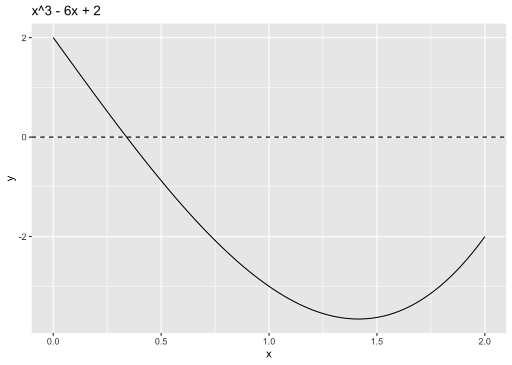

```
##
## ### Ejercicio 1.3: exp(-x) - x
##     k         a         b         c         fa          fb          fc
## 1   1 0.0000000 1.0000000 0.5000000 1.00000000 -0.63212056  0.10653066
## 2   2 0.5000000 1.0000000 0.7500000 0.10653066 -0.63212056 -0.27763345
## 3   3 0.5000000 0.7500000 0.6250000 0.10653066 -0.27763345 -0.08973857
## 4   4 0.5000000 0.6250000 0.5625000 0.10653066 -0.08973857  0.00728282
## 5   5 0.5625000 0.6250000 0.5937500 0.00728282 -0.08973857 -0.04149755
## 6   6 0.5625000 0.5937500 0.5781250 0.00728282 -0.04149755 -0.01717584
## 7   7 0.5625000 0.5781250 0.5703125 0.00728282 -0.01717584 -0.00496376
## 8   8 0.5625000 0.5703125 0.5664062 0.00728282 -0.00496376  0.00115520
## 9   9 0.5664062 0.5703125 0.5683594 0.00115520 -0.00496376 -0.00190536
## 10 10 0.5664062 0.5683594 0.5673828 0.00115520 -0.00190536 -0.00037535
## 11 11 0.5664062 0.5673828 0.5668945 0.00115520 -0.00037535  0.00038986
## 12 12 0.5668945 0.5673828 0.5671387 0.00038986 -0.00037535  0.00000724
##        signo      error
## 1  fa*fc > 0 1.00000000
## 2  fa*fc < 0 0.50000000
## 3  fa*fc < 0 0.25000000
## 4  fa*fc > 0 0.12500000
## 5  fa*fc < 0 0.06250000
## 6  fa*fc < 0 0.03125000
## 7  fa*fc < 0 0.01562500
## 8  fa*fc > 0 0.00781250
## 9  fa*fc < 0 0.00390625
## 10 fa*fc < 0 0.00195312
## 11 fa*fc > 0 0.00097656
## 12 fa*fc > 0 0.00048828
```

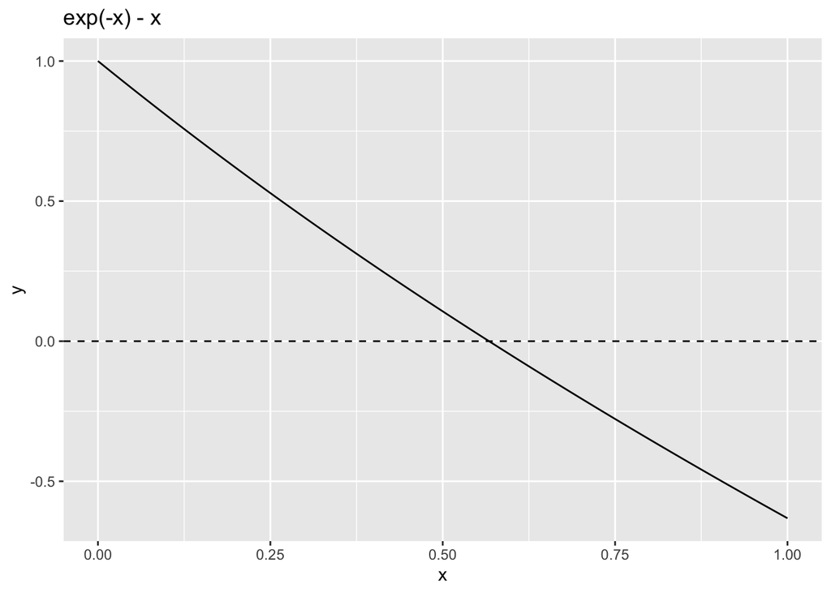

```
##
## ### Ejercicio 1.3: x^2 - 4
##     k         a        b        c          fa          fb          fc     signo
## 1   1 -1.000000 4.000000 1.500000 -3.00000000 12.00000000 -1.75000000 fa*fc > 0
## 2   2  1.500000 4.000000 2.750000 -1.75000000 12.00000000  3.56250000 fa*fc < 0
## 3   3  1.500000 2.750000 2.125000 -1.75000000  3.56250000  0.51562500 fa*fc < 0
## 4   4  1.500000 2.125000 1.812500 -1.75000000  0.51562500 -0.71484375 fa*fc > 0
## 5   5  1.812500 2.125000 1.968750 -0.71484375  0.51562500 -0.12402344 fa*fc > 0
## 6   6  1.968750 2.125000 2.046875 -0.12402344  0.51562500  0.18969727 fa*fc < 0
## 7   7  1.968750 2.046875 2.007812 -0.12402344  0.18969727  0.03131104 fa*fc < 0
## 8   8  1.968750 2.007812 1.988281 -0.12402344  0.03131104 -0.04673767 fa*fc > 0
## 9   9  1.988281 2.007812 1.998047 -0.04673767  0.03131104 -0.00780869 fa*fc > 0
## 10 10  1.998047 2.007812 2.002930 -0.00780869  0.03131104  0.01172733 fa*fc < 0
## 11 11  1.998047 2.002930 2.000488 -0.00780869  0.01172733  0.00195336 fa*fc < 0
## 12 12  1.998047 2.000488 1.999268 -0.00780869  0.00195336 -0.00292915 fa*fc > 0
##         error
## 1  5.00000000
## 2  2.50000000
## 3  1.25000000
## 4  0.62500000
## 5  0.31250000
## 6  0.15625000
## 7  0.07812500
## 8  0.03906250
## 9  0.01953125
## 10 0.00976562
## 11 0.00488281
## 12 0.00244141
```

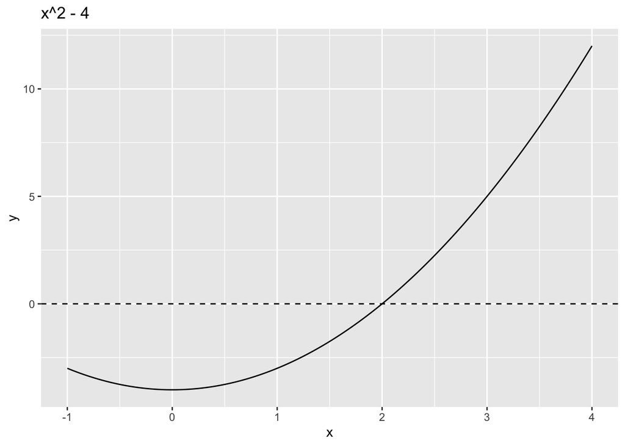

```r
f1_1 <- function(x) x^3 - 6*x + 2
f1_2 <- function(x) exp(-x) - x
f1_3 <- function(x) x^2 - 4

casos <- list(
  list(f=f1_1, a=0, b=2, n=12, nombre="x^3 - 6x + 2"),
  list(f=f1_2, a=0, b=1, n=12, nombre="exp(-x) - x"),
  list(f=f1_3, a=-1, b=4, n=12, nombre="x^2 - 4")
)

for(i in seq_along(casos)){
  caso <- casos[[i]]
  res <- biseccion(caso$f, caso$a, caso$b, caso$n)

  cat("\n### Ejercicio 1.3:", caso$nombre, "\n")

  tabla <- res$hist
  tabla[, sapply(tabla, is.numeric)] <- round(tabla[, sapply(tabla, is.numeric)], 8)
  print(tabla)

  print(grafica_biseccion(caso$f, res$hist, caso$nombre))
}
```

## Punto 5.1 — Bisección

```
##
## ### 5.1: x^2 - 5
##   k        a        b        c          fa         fb          fc     signo
## 1 1 2.000000 3.000000 2.500000 -1.00000000 4.00000000  1.25000000 fa*fc < 0
## 2 2 2.000000 2.500000 2.250000 -1.00000000 1.25000000  0.06250000 fa*fc < 0
## 3 3 2.000000 2.250000 2.125000 -1.00000000 0.06250000 -0.48437500 fa*fc > 0
## 4 4 2.125000 2.250000 2.187500 -0.48437500 0.06250000 -0.21484375 fa*fc > 0
## 5 5 2.187500 2.250000 2.218750 -0.21484375 0.06250000 -0.07714844 fa*fc > 0
## 6 6 2.218750 2.250000 2.234375 -0.07714844 0.06250000 -0.00756836 fa*fc > 0
## 7 7 2.234375 2.250000 2.242188 -0.00756836 0.06250000  0.02740479 fa*fc < 0
## 8 8 2.234375 2.242188 2.238281 -0.00756836 0.02740479  0.00990295 fa*fc < 0
##       error
## 1 1.0000000
## 2 0.5000000
## 3 0.2500000
## 4 0.1250000
## 5 0.0625000
## 6 0.0312500
## 7 0.0156250
## 8 0.0078125
```

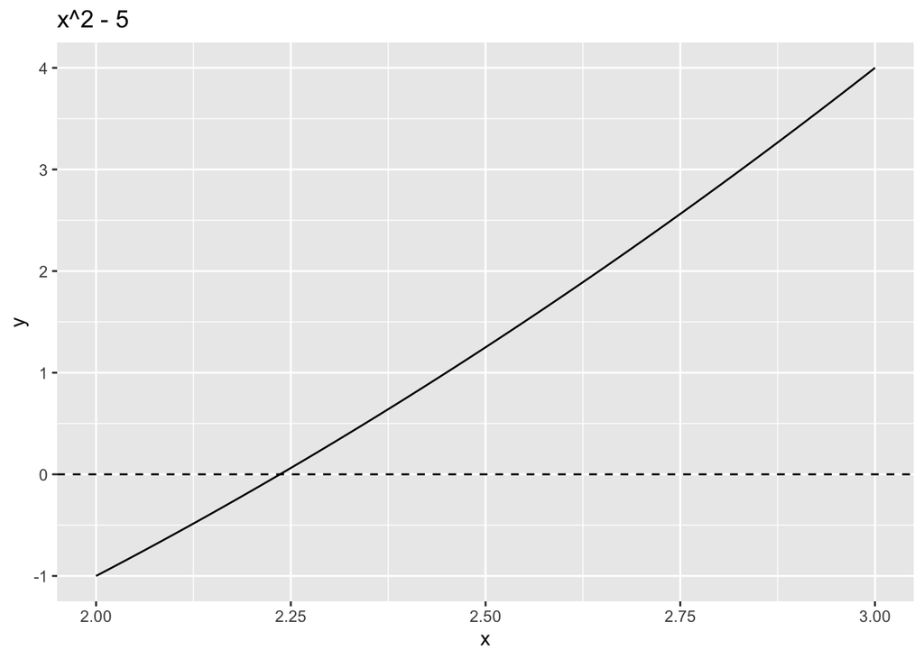

```r
f_list_5_1 <- list(
  list(f=function(x) x^2 - 5, a=2, b=3, nombre="x^2 - 5")
)

for(i in seq_along(f_list_5_1)){
  caso <- f_list_5_1[[i]]

  res <- try(biseccion(caso$f, caso$a, caso$b, 8), silent=TRUE)
  if(inherits(res, "try-error")){
    cat("\nError en:", caso$nombre, "\n")
    next
  }

  cat("\n### 5.1:", caso$nombre, "\n")
  tabla <- res$hist
  tabla[, sapply(tabla, is.numeric)] <- round(tabla[, sapply(tabla, is.numeric)], 8)
  print(tabla)
  print(grafica_biseccion(caso$f, res$hist, caso$nombre))
}
```

## Punto 5.2 — Secante

```r
f_list_5_2 <- list(
  list(f=function(x) x^2 - 2*x -3, x0=0, x1=3, nombre="x^2 - 2x -3")
)

for(i in seq_along(f_list_5_2)){
  caso <- f_list_5_2[[i]]

  res <- try(secante(caso$f, caso$x0, caso$x1), silent=TRUE)
  if(inherits(res, "try-error")){
    cat("\nError en:", caso$nombre, "\n")
    next
  }

  cat("\n### 5.2:", caso$nombre, "\n")
  tabla <- res$hist
  tabla[, sapply(tabla, is.numeric)] <- round(tabla[, sapply(tabla, is.numeric)], 8)
  print(tabla)
}
```

```
##
## ### 5.2: x^2 - 2x -3
##   k x_prev x_curr f_curr x_next error
## 1 1      0      3      0      3     0
```

## Ejercicios a mano

# Interpolación

# Ejercicios a mano